# Exercises

Tetiana Matviichuk

30 06 2020

```r
library(tidyverse)
```

```r
library(nycflights13)
library(ggplot2)
(flights)
```

```
## # A tibble: 336,776 x 19
##     year month   day dep_time sched_dep_time dep_delay arr_time sched_arr_time
##    <int> <int> <int>    <int>          <int>     <dbl>    <int>          <int>
##  1  2013     1     1      517            515         2      830            819
##  2  2013     1     1      533            529         4      850            830
##  3  2013     1     1      542            540         2      923            850
##  4  2013     1     1      544            545        -1     1004           1022
##  5  2013     1     1      554            600        -6      812            837
##  6  2013     1     1      554            558        -4      740            728
##  7  2013     1     1      555            600        -5      913            854
##  8  2013     1     1      557            600        -3      709            723
##  9  2013     1     1      557            600        -3      838            846
## 10  2013     1     1      558            600        -2      753            745
## # ... with 336,766 more rows, and 11 more variables: arr_delay <dbl>,
## #   carrier <chr>, flight <int>, tailnum <chr>, origin <chr>, dest <chr>,
## #   air_time <dbl>, distance <dbl>, hour <dbl>, minute <dbl>, time_hour <dttm>
```

```r
not_cancelled <- flights %>%
  filter(!is.na(dep_delay), !is.na(arr_delay))
```

## Exercises

1. Brainstorm at least 5 different ways to assess the typical delay characteristics of a group of flights. Consider the following scenarios:
   - A flight is 15 minutes early 50% of the time, and 15 minutes late 50% of the time (**WRONG**).

```r
fifteen_min <- not_cancelled %>%
  group_by(tailnum) %>%
  summarise(
    median_delay = median(arr_delay, na.rm = T)
  ) %>%
  filter(median_delay == 15 | - 15)
(fifteen_min)
```

```
## # A tibble: 4,037 x 2
##    tailnum median_delay
##    <chr>          <dbl>
##  1 D942DN          23
##  2 N0EGMQ          -2
##  3 N10156           2
##  4 N102UW          -6.5
##  5 N103US          -7
##  6 N104UW          -8.5
##  7 N10575          -2
##  8 N105UW          -7
##  9 N107US          -9
## 10 N108UW         -10
## # ... with 4,027 more rows
```

```
* A flight is always 10 minutes late:
```

```r
ten_minutes <- not_cancelled %>%
  group_by(tailnum) %>%
  filter(arr_delay == 10)

(ten_minutes)
```

```
## # A tibble: 3,373 x 19
## # Groups:   tailnum [1,834]
##     year month   day dep_time sched_dep_time dep_delay arr_time sched_arr_time
##    <int> <int> <int>    <int>          <int>     <dbl>    <int>          <int>
##  1  2013     1     1      624            630        -6      840            830
##  2  2013     1     1      717            720        -3      850            840
##  3  2013     1     1      745            745         0     1135           1125
##  4  2013     1     1      805            805         0     1015           1005
##  5  2013     1     1      811            815        -4     1026           1016
##  6  2013     1     1      921            900        21     1237           1227
##  7  2013     1     1     1158           1205        -7     1530           1520
##  8  2013     1     1     1211           1215        -4     1423           1413
##  9  2013     1     1     1455           1459        -4     1655           1645
## 10  2013     1     1     1554           1600        -6     1830           1820
## # ... with 3,363 more rows, and 11 more variables: arr_delay <dbl>,
## #   carrier <chr>, flight <int>, tailnum <chr>, origin <chr>, dest <chr>,
## #   air_time <dbl>, distance <dbl>, hour <dbl>, minute <dbl>, time_hour <dttm>
```

OR:

```r
not_cancelled[which(not_cancelled$arr_delay == 10), ]
```

```
## # A tibble: 3,373 x 19
##     year month   day dep_time sched_dep_time dep_delay arr_time sched_arr_time
##    <int> <int> <int>    <int>          <int>     <dbl>    <int>          <int>
##  1  2013     1     1      624            630        -6      840            830
##  2  2013     1     1      717            720        -3      850            840
##  3  2013     1     1      745            745         0     1135           1125
##  4  2013     1     1      805            805         0     1015           1005
##  5  2013     1     1      811            815        -4     1026           1016
##  6  2013     1     1      921            900        21     1237           1227
##  7  2013     1     1     1158           1205        -7     1530           1520
##  8  2013     1     1     1211           1215        -4     1423           1413
##  9  2013     1     1     1455           1459        -4     1655           1645
## 10  2013     1     1     1554           1600        -6     1830           1820
## # ... with 3,363 more rows, and 11 more variables: arr_delay <dbl>,
## #   carrier <chr>, flight <int>, tailnum <chr>, origin <chr>, dest <chr>,
## #   air_time <dbl>, distance <dbl>, hour <dbl>, minute <dbl>, time_hour <dttm>
```

```
* A flight is 30 minutes early 50% of the time, and 30 minutes late 50% of the time.

* 99% of the time a flight is on time. 1% of the time it’s 2 hours late.

Which is more important: arrival delay or departure delay?
```

In most cases, arrival delay is more important as it impacts negatively more.

2. Come up with another approach that will give you the same output as not_cancelled %>% count(dest) and not_cancelled %>% count(tailnum, wt = distance) (without using count()).

```r
# First case:
not_cancelled %>% count(dest)
```

```
## # A tibble: 104 x 2
##    dest      n
##    <chr> <int>
##  1 ABQ     254
##  2 ACK     264
##  3 ALB     418
##  4 ANC       8
##  5 ATL   16837
##  6 AUS    2411
##  7 AVL     261
##  8 BDL     412
##  9 BGR     358
## 10 BHM     269
## # ... with 94 more rows
```

```r
# The same as:
not_cancelled %>%
  group_by(dest) %>%
  summarise(
    n = n()
  )
```

```
## # A tibble: 104 x 2
##    dest      n
##    <chr> <int>
##  1 ABQ     254
##  2 ACK     264
##  3 ALB     418
##  4 ANC       8
##  5 ATL   16837
##  6 AUS    2411
##  7 AVL     261
##  8 BDL     412
##  9 BGR     358
## 10 BHM     269
## # ... with 94 more rows
```

```r
# Second case:
not_cancelled %>% count(tailnum, wt = distance)
```

```
## # A tibble: 4,037 x 2
##    tailnum      n
##    <chr>    <dbl>
##  1 D942DN    3418
##  2 N0EGMQ  239143
##  3 N10156  109664
##  4 N102UW   25722
##  5 N103US   24619
##  6 N104UW   24616
##  7 N10575  139903
##  8 N105UW   23618
##  9 N107US   21677
## 10 N108UW   32070
## # ... with 4,027 more rows
```

```r
#The same as:
not_cancelled %>%
  group_by(tailnum) %>%
  summarise(
    count = sum(distance)
  )
```

```
## # A tibble: 4,037 x 2
##    tailnum  count
##    <chr>    <dbl>
##  1 D942DN    3418
##  2 N0EGMQ  239143
##  3 N10156  109664
##  4 N102UW   25722
##  5 N103US   24619
##  6 N104UW   24616
##  7 N10575  139903
##  8 N105UW   23618
##  9 N107US   21677
## 10 N108UW   32070
## # ... with 4,027 more rows
```

3. Our definition of cancelled flights (is.na(dep_delay) | is.na(arr_delay) ) is slightly suboptimal. Why? Which is the most important column?

```r
flights %>% select(starts_with("dep"), starts_with("arr")) %>%
  sapply(function(x){sum(is.na(x))})
```

```
##  dep_time dep_delay  arr_time arr_delay
##      8255      8255      8713      9430
```

```r
# One possible explanation is that those flights did actually take off, but arrived at a different airport or were forced to return to the origins
# To confirm hypothesis, we can look at the number of observations with non missing departure time and missing arrival time:
nrow(flights %>% filter(!is.na(dep_time), is.na(arr_time)))
```

```
## [1] 458
```

So, dep_time or arr_time should be used to filter cancelled flights.

4. Look at the number of cancelled flights per day. Is there a pattern? Is the proportion of cancelled flights related to the average delay?

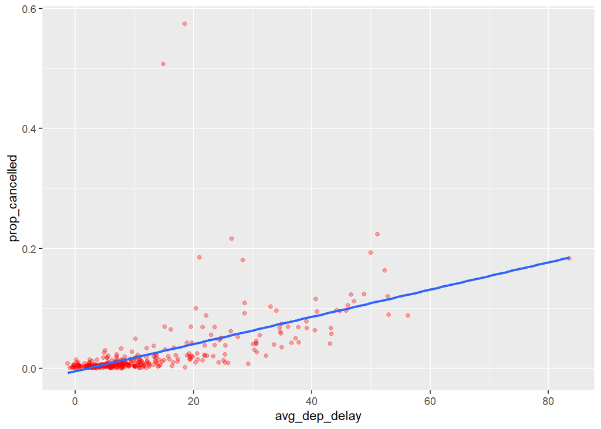

```r
flights %>%
  group_by(month, day) %>%
  summarise(
    n = n(),
    avg_dep_delay = mean(dep_delay, na.rm = T),
    prop_cancelled = sum(is.na(dep_delay))/n
  ) %>%
  ggplot(mapping = aes(x = avg_dep_delay, y = prop_cancelled)) +
  geom_point(alpha = 1/3, color = "red") +
  geom_smooth(method = 'lm', se = FALSE)
```

5. Which carrier has the worst delays? Challenge: can you disentangle the effects of bad airports vs. bad carriers? Why/why not? (Hint: think about flights %>% group_by(carrier, dest) %>% summarise(n()))

```r
airports_vs_carrier <- flights %>%
  group_by(carrier, dest) %>%
  summarise(
    n = n(),
    delay_prop = mean(arr_delay, na.rm = T),
    arr_delay = sum(arr_delay, na.rm = T)
    ) %>%
  arrange(desc(arr_delay))
(airports_vs_carrier)
```

```
## # A tibble: 314 x 5
## # Groups:   carrier [16]
##    carrier dest      n delay_prop arr_delay
##    <chr>   <chr> <int>      <dbl>     <dbl>
##  1 DL      ATL   10571       7.42     77598
##  2 B6      FLL    6563      12.0      77376
##  3 B6      MCO    6472      11.5      73996
##  4 EV      IAD    4048      15.5      59196
##  5 WN      MDW    4113      12.4      49766
##  6 FL      ATL    2337      20.7      47256
##  7 EV      CLT    2508      18.9      44976
##  8 B6      PBI    3161      13.9      43454
##  9 EV      RIC    2114      21.2      42963
## 10 UA      ORD    6984       6.07     40910
## # ... with 304 more rows
```

```r
bad_airports <- flights %>%
  # ungroup() %>%
  group_by(dest) %>%
  summarise(
    delay_prop = mean(arr_delay, na.rm = T),
    arr_delay = sum(arr_delay, na.rm = T)
  ) %>%
  arrange(desc(arr_delay))
(bad_airports)
```

```
## # A tibble: 105 x 3
##    dest  delay_prop arr_delay
##    <chr>      <dbl>     <dbl>
##  1 ATL        11.3     190260
##  2 CLT         7.36    100645
##  3 ORD         5.88     97352
##  4 FLL         8.08     96153
##  5 DCA         9.07     82609
##  6 RDU        10.1      78107
##  7 MCO         5.45     76185
##  8 IAD        13.9      74631
##  9 BNA        11.8      71867
## 10 DEN         8.61     61700
## # ... with 95 more rows
```

```r
bad_carriers <- flights %>%
  # ungroup() %>%
  group_by(carrier) %>%
  summarise(
    delay_prop = mean(arr_delay, na.rm = T),
    arr_delay = sum(arr_delay, na.rm = T)
  ) %>%
  arrange(desc(arr_delay))
# plot(x = bad_carriers$arr_delay, y = bad_carriers$delay_prop, type = 'p')
(bad_carriers)
```

```
## # A tibble: 16 x 3
##    carrier delay_prop arr_delay
##    <chr>        <dbl>     <dbl>
##  1 EV          15.8      807324
##  2 B6           9.46     511194
##  3 MQ          10.8      269767
##  4 UA           3.56     205589
##  5 9E           7.38     127624
##  6 WN           9.65     116214
##  7 DL           1.64      78366
##  8 FL          20.1       63868
##  9 US           2.13      42232
## 10 F9          21.9       14928
## 11 AA           0.364     11638
## 12 VX           1.76       9027
## 13 YV          15.6        8463
## 14 OO          11.9         346
## 15 HA          -6.92      -2365
## 16 AS          -9.93      -7041
```

```r
not_cancelled %>%
  count(carrier, wt = arr_delay) #just to be sure that the code is right
```

```
## # A tibble: 16 x 2
##    carrier      n
##    <chr>    <dbl>
##  1 9E      127624
##  2 AA       11638
##  3 AS       -7041
##  4 B6      511194
##  5 DL       78366
##  6 EV      807324
##  7 F9       14928
##  8 FL       63868
##  9 HA       -2365
## 10 MQ      269767
## 11 OO         346
## 12 UA      205589
## 13 US       42232
## 14 VX        9027
## 15 WN      116214
## 16 YV        8463
```

6. What does the sort argument to count() do. When might you use it?